# Self-Driving Car Engineer Nanodegree

## Step 0: Load The Data

```python
# Load pickled data
import pickle

training_file = "./traffic-signs-data/train.p"
validation_file= "./traffic-signs-data/valid.p"
testing_file = "./traffic-signs-data/test.p"

with open(training_file, mode='rb') as f:
    train = pickle.load(f)
with open(validation_file, mode='rb') as f:
    valid = pickle.load(f)
with open(testing_file, mode='rb') as f:
    test = pickle.load(f)

X_train, y_train = train['features'], train['labels']
X_valid, y_valid = valid['features'], valid['labels']
X_test, y_test = test['features'], test['labels']
```

## Step 1: Dataset Summary & Exploration

The pickled data is a dictionary with 4 key/value pairs:

- `'features'` is a 4D array containing raw pixel data of the traffic sign images, (num examples, width, height, channels).
- `'labels'` is a 1D array containing the label/class id of the traffic sign. The file `signnames.csv` contains id -> name mappings for each id.
- `'sizes'` is a list containing tuples, (width, height) representing the original width and height the image.
- `'coords'` is a list containing tuples, (x1, y1, x2, y2) representing coordinates of a bounding box around the sign in the image. These coordinates assume the original image. The pickled data contains resized versions (32 by 32) of these images.

Below, we provide a basic summary of our dataset.

We see that there are 34,799 training examples and 12,630 testing samples. Each image is 32 pixels by 32 pixels. There are 43 classes for the images, i.e. there are 43 different traffic signs in the dataset.

```python
import numpy as np

# Number of training examples
n_train = len(X_train)

# Number of testing examples.
n_test = len(X_test)

# shape of an traffic sign image
image_shape = X_train[0].shape

# classes/labels there are in the dataset.
n_classes = np.unique(y_train).size

print("Number of training examples =", n_train)
print("Number of testing examples =", n_test)
print("Image data shape =", image_shape)
print("Number of classes =", n_classes)
```

```
Number of training examples = 34799
Number of testing examples = 12630
Image data shape = (32, 32, 3)
Number of classes = 43
```

### An exploratory visualization of the dataset

We create some visualizations to help us understand the dataset better. We first print a random image from the dataset. Using matplotlib, we create a bar graph showing the number of images corresponding to each class. The name of the sign corresponding to the image class number can be found in the `signnames.csv` file.

```
4
```

[figure not shown]

```python
### we print a randomly chosen image
import random
import matplotlib.pyplot as plt
%matplotlib inline

index = random.randint(0, len(X_train))
image = X_train[index].squeeze()

plt.figure(figsize=(2,2))
plt.imshow(image)
print(y_train[index])
```

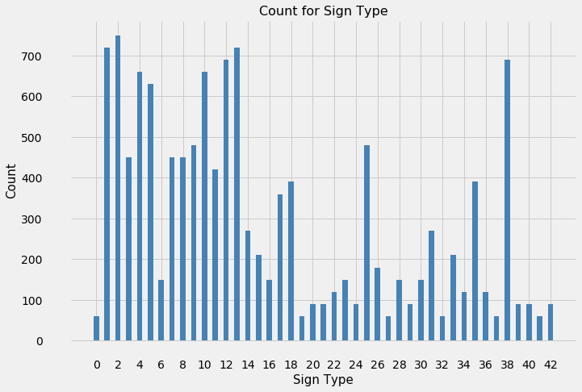

```python
### We build a plot to display the number of images corresponding to each label/class.
import matplotlib.pyplot as plt
# Visualizations will be shown in the notebook.
%matplotlib inline

sign_dict = {}
for label in y_test:
    if label in sign_dict:
        sign_dict[label] += 1
    else:
        sign_dict[label] = 1

# Building plot :D
with plt.style.context('fivethirtyeight'):
    #initialize figure
    fig = plt.figure(figsize= (10,15))

    #first axis
    ax1 = fig.add_subplot(2, 1, 1)
    ax1.bar(list(sign_dict.keys()), list(sign_dict.values()), color="steelblue", width=0.5)
    ax1.set_xlabel("Sign Type", fontsize=15)
    ax1.set_ylabel("Count", fontsize=15)

    #adjust x-axis ticks
    plt.xticks(range(0, 43, 2), size='small')

    #more adjusting
    for axis in ['bottom','left']:
        ax1.spines[axis].set_linewidth(1)
        ax1.spines[axis].set_position(("axes", -0.05))

    #add a title
    plt.title('Count for Sign Type', fontsize=16)
```

## Step 2: Design and Test a Model Architecture

We design and implement a deep learning model that learns to recognize traffic signs. The model is trained and tested on the [German Traffic Sign Dataset](http://benchmark.ini.rub.de/?section=gtsrb&subsection=dataset).

We use the classic Lenet-5 architecture. The key modifications we made in order to increase the validation accuracy to over 0.930 was the inclusion of dropout after each of the two fully connected layers. Our validation accuracy is found to be over 0.930 and preprocessing the data. For preprocessing the data, we convert the images to grayscale and normalize them.

### Pre-process the Data Set (normalization, grayscale, etc.)

For the preprocessing of the data, we choose to normalize the images and convert to grayscale. Normalization is used to ensure all the images are in a similar pixel range. This also helps make photos that might have high glare or other problems easier to process and understand. We convert to grayscale because it simplifies the images significantly and reduces processing time.

```python
### These functions are used to preprocess the data.
### We convert the images to grayscale and normalize them.

import cv2
from numpy import newaxis

# function which converts an image to grayscale
def grayscale(image):
    image = cv2.cvtColor(image, cv2.COLOR_BGR2GRAY)
    return image

def normalize(image):
    minimum = 0.1
    output = image / 255 * 0.8 + minimum
    return output

def preprocess(data):
    processed = []
    for image in data:
        processed.append(grayscale(image))
    return np.array(processed)

# print the shape of the data beforehand just to check
print(X_train.shape)
```

```
(34799, 32, 32, 3)
```

```python
## The data is actually preprocessed in this cell
from sklearn.utils import shuffle

# training set
X_train = preprocess(X_train)
X_train = X_train[..., newaxis]

X_train = normalize(X_train)

# test set
X_test = preprocess(X_test)
X_test = X_test[..., newaxis]

X_test = normalize(X_test)

# validation set
X_valid = preprocess(X_valid)
X_valid = X_valid[..., newaxis]

X_valid = normalize(X_valid)

# we also shuffle the data beforehand.
X_train, y_train = shuffle(X_train, y_train)

# print the shape of an image after preprocessing
print(X_train.shape)
print(X_test.shape)
print(X_valid.shape)
```

```
(34799, 32, 32, 1)
(12630, 32, 32, 1)
(4410, 32, 32, 1)
```

### Model Architecture

We choose a batch size of 128 with 30 epochs. The batch size is chosen not to be larger, so that the model does not lose the ability to generalize. A smaller batch size is not chosen lest there are too few examples. We settled on 128, though a similar number would work similarly well. We choose 30 epochs, because when training the model for less epochs, we found that the model was still improving signifantly even when the model was done. After 30 epochs, it seems the model reaches a validation accuracy which it would hover around even if additional epochs were added.

We began by using the classic Lenet-5 architecture. This led to a validation accuracy of around 0.88. We then preprocessed the images and used the same architecture, only adjusting slightly to account for the new input pixel size. This helped increased the validation accuracy, but there seemed to be overfitting, comparing the validation accruacy to the test set accuracy. The next adjustment was to add two dropout layers after each of the fully connected layers to prevent overfitting. This is how we reached the model that is seen above.

Other relevant parameters include

```python
## We import tensorflow and set our epoch size to 30 and our batch size to 128
import tensorflow as tf

EPOCHS = 30
BATCH_SIZE = 128
```

```python
### We use the Lenet-5 architecture but add two dropouts after the two fully connected layers.
from tensorflow.contrib.layers import flatten

def LeNet(x):
    # Arguments used for tf.truncated_normal, randomly defines variables for the weights and biases for each layer
    mu = 0
    sigma = 0.1

    # Layer 1: Convolutional. Input = 32x32x1. Output = 28x28x6.
    conv1_W = tf.Variable(tf.truncated_normal(shape=(5, 5, 1, 6), mean = mu, stddev = sigma))
    conv1_b = tf.Variable(tf.zeros(6))
    conv1   = tf.nn.conv2d(x, conv1_W, strides=[1, 1, 1, 1], padding='VALID') + conv1_b

    # Activation.
    conv1 = tf.nn.relu(conv1)

    # Pooling. Input = 28x28x6. Output = 14x14x6.
    conv1 = tf.nn.max_pool(conv1, ksize=[1, 2, 2, 1], strides=[1, 2, 2, 1], padding='VALID')

    # Layer 2: Convolutional. Output = 10x10x16.
    conv2_W = tf.Variable(tf.truncated_normal(shape=(5, 5, 6, 16), mean = mu, stddev = sigma))
    conv2_b = tf.Variable(tf.zeros(16))
    conv2   = tf.nn.conv2d(conv1, conv2_W, strides=[1, 1, 1, 1], padding='VALID') + conv2_b

    # Activation.
    conv2 = tf.nn.relu(conv2)

    # Pooling. Input = 10x10x16. Output = 5x5x16.
    conv2 = tf.nn.max_pool(conv2, ksize=[1, 2, 2, 1], strides=[1, 2, 2, 1], padding='VALID')

    # Flatten. Input = 5x5x16. Output = 400.
    fc0   = flatten(conv2)

    # Layer 3: Fully Connected. Input = 400. Output = 120.
    fc1_W = tf.Variable(tf.truncated_normal(shape=(400, 120), mean = mu, stddev = sigma))
    fc1_b = tf.Variable(tf.zeros(120))
    fc1   = tf.matmul(fc0, fc1_W) + fc1_b

    # Activation.
    fc1    = tf.nn.relu(fc1)

    # Dropout.
    fc1 = tf.nn.dropout(fc1, keep)

    # Layer 4: Fully Connected. Input = 120. Output = 84.
    fc2_W  = tf.Variable(tf.truncated_normal(shape=(120, 84), mean = mu, stddev = sigma))
    fc2_b  = tf.Variable(tf.zeros(84))
    fc2    = tf.matmul(fc1, fc2_W) + fc2_b

    # Activation.
    fc2    = tf.nn.relu(fc2)

    # Dropout.
    fc2 = tf.nn.dropout(fc2, keep)

    # Layer 5: Fully Connected. Input = 84. Output = 10.
    fc3_W  = tf.Variable(tf.truncated_normal(shape=(84, 43), mean = mu, stddev = sigma))
    fc3_b  = tf.Variable(tf.zeros(43))
    logits = tf.matmul(fc2, fc3_W) + fc3_b

    return logits
```

```python
### Define our tensorflow variables. Apply one-hot encoding.

x = tf.placeholder(tf.float32, (None, 32, 32, 1))
y = tf.placeholder(tf.int32, (None))

keep = tf.placeholder(tf.float32)

one_hot_y = tf.one_hot(y, 43)
```

### Train, Validate and Test the Model

We apply TensorFlow's cross entropy function to the Logits, and also use the Adam Optimizer with a learning rate of 0.005. For the learning rate, we attempted training the model with a rate of 0.001 and a rate of 0.01, but found that 0.005 provided the best results.

```python
### We set the learning rate, and store the logits returned by our training model.
rate = 0.005

logits = LeNet(x)
cross_entropy = tf.nn.softmax_cross_entropy_with_logits(logits, one_hot_y)
loss_operation = tf.reduce_mean(cross_entropy)
optimizer = tf.train.AdamOptimizer(learning_rate = rate)
training_operation = optimizer.minimize(loss_operation)
```

```python
### This is the function to test our validation accuracy.
correct_prediction = tf.equal(tf.argmax(logits, 1), tf.argmax(one_hot_y, 1))
accuracy_operation = tf.reduce_mean(tf.cast(correct_prediction, tf.float32))
saver = tf.train.Saver()

def evaluate(X_data, y_data):
    example_count = len(X_data)
    total_accuracy = 0
    sess = tf.get_default_session()
    for offset in range(0, example_count, BATCH_SIZE):
        batch_x, batch_y = X_data[offset:offset+BATCH_SIZE], y_data[offset:offset+BATCH_SIZE]
        accuracy = sess.run(accuracy_operation, feed_dict={x: batch_x, y: batch_y, keep: 1.0})
        total_accuracy += (accuracy * len(batch_x))
    return total_accuracy / example_count
```

```python
### We train the model here.
saver = tf.train.Saver()
training_model = '/tmp/model.ckpt'

with tf.Session() as sess:
    sess.run(tf.global_variables_initializer())
    n_train = len(X_train)

    print("Training...")
    print()
    for i in range(EPOCHS):
        X_train, y_train = shuffle(X_train, y_train)
        for offset in range(0, n_train, BATCH_SIZE):
            end = offset + BATCH_SIZE
            batch_x, batch_y = X_train[offset:end], y_train[offset:end]
            sess.run(training_operation, feed_dict={x: batch_x, y: batch_y, keep: 0.7})

        validation_accuracy = evaluate(X_valid, y_valid)
        print("EPOCH {} ...".format(i+1))
        print("Validation Accuracy = {:.3f}".format(validation_accuracy))
        print()

    saver.save(sess, training_model)
    print("Model saved")

### We also calculate the accuracy on the training set.
```

[output not shown]

```
Training...

EPOCH 1 ...
Validation Accuracy = 0.736

EPOCH 2 ...
Validation Accuracy = 0.836

EPOCH 3 ...
Validation Accuracy = 0.865

EPOCH 4 ...
Validation Accuracy = 0.870

EPOCH 5 ...
Validation Accuracy = 0.897

EPOCH 6 ...
Validation Accuracy = 0.904

EPOCH 7 ...
Validation Accuracy = 0.902

EPOCH 8 ...
Validation Accuracy = 0.900

EPOCH 9 ...
Validation Accuracy = 0.906

EPOCH 10 ...
Validation Accuracy = 0.900

EPOCH 11 ...
Validation Accuracy = 0.911

EPOCH 12 ...
Validation Accuracy = 0.922

EPOCH 13 ...
Validation Accuracy = 0.907
```

[output cut: 38 more lines]

```
Validation Accuracy = 0.926

EPOCH 27 ...
Validation Accuracy = 0.938

EPOCH 28 ...
Validation Accuracy = 0.938

EPOCH 29 ...
Validation Accuracy = 0.934

EPOCH 30 ...
Validation Accuracy = 0.935

Model saved
```

### Test set accuracy

A test set is used to assess how well the model is performing. A low accuracy on the training and test sets imply underfitting. A high accuracy on the training set but low accuracy on the test set implies overfitting. We find a test set accuracy of 0.9087 which implies slight overfitting.

```python
# Run the model on the test data
with tf.Session() as sess:
    saver.restore(sess, training_model)

    test_accuracy = sess.run(accuracy_operation, feed_dict={x: X_test, y: y_test, keep: 1.0})

print('Test Accuracy: {}'.format(test_accuracy))
```

```
Test Accuracy: 0.9087886214256287
```

## Step 3: Test a Model on New Images

To give better insight into how our model is working, we download at least five pictures of German traffic signs from the web and use your model to predict the traffic sign type. Each of the signs are edited to the 32x32 pixel size. Among the images, we predict that the model may have trouble identifying the exact speed of the speed limit sign, though it will likely know that it is a speed limit sign in general. Another aspect that may make the images difficult too identify is that the traffic signs fill out the whole image, while in the training set, a larger portion of the background was included in the image.

### Load and Output the Images

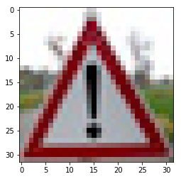

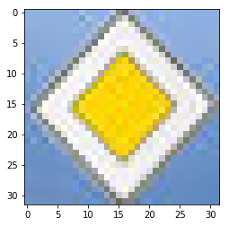

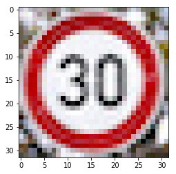

[figure not shown]

[figure not shown]

```python
### We load the 5 images from the web after adjusting them to the 32x32 pixel size.
import os
import matplotlib.image as mpimg

images = os.listdir('./five_german_signs/')

image_data = []
for i in images:
    i = './five_german_signs/' + i
    if os.path.isdir(i) == True:
        pass
    else:
        image = mpimg.imread(i)
        image_data.append(image)
        plt.imshow(image)
        plt.show()
```

### Predict the Sign Type for Each Image

```python
### We turn the image data from a list into an array.
image_data = np.array(image_data)

# check that np.array worked as expected
print(type(image_data))
print(image_data.shape)
```

```
<class 'numpy.ndarray'>
(5, 32, 32, 3)
```

```python
### We preprocess the images the same way we did before.
image_data = preprocess(image_data)
image_data = image_data[..., newaxis]

image_data = normalize(image_data)

# check that preprocessing worked.
print(image_data[0].shape)
```

```
(32, 32, 1)
```

### Output Top 5 Softmax Probabilities For Each Image Found on the Web

```python
### We restore the session, then calculate the accuracy of the model.
### We print out the top five softmax probabilities for the predictions
### on the German traffic sign images found on the web.
predicted_labels = tf.nn.softmax(logits)

with tf.Session() as sess:
    saver.restore(sess, training_model)
    images_classified = sess.run(predicted_labels, feed_dict={x: image_data, keep: 1.0})
    output = sess.run(tf.nn.top_k(images_classified, k=5))
```

```python
for i in range(len(output[0])):
    print('Image', i + 1, 'probabilities:', output[0][i], '\n and predicted classes:', output[1][i], '\n')
```

```
Image 1 probabilities: [  9.99212503e-01   7.38888572e-04   2.80856075e-05   6.68800112e-06
   5.49343576e-06]
 and predicted classes: [18 26 25 37 11]

Image 2 probabilities: [  1.00000000e+00   2.65541428e-30   3.36389271e-33   3.67955305e-38
   0.00000000e+00]
 and predicted classes: [12 40 38 13  0]

Image 3 probabilities: [  9.92345512e-01   5.94330812e-03   1.01539923e-03   4.50484658e-04
   1.70391606e-04]
 and predicted classes: [ 1 42 40 12 33]

Image 4 probabilities: [  1.00000000e+00   1.23399008e-26   7.70515580e-29   1.21322090e-31
   7.02279447e-38]
 and predicted classes: [13 36 35 12 38]

Image 5 probabilities: [  1.00000000e+00   1.92055717e-36   3.23514099e-37   0.00000000e+00
   0.00000000e+00]
 and predicted classes: [17  9 14  0  1]
```

### Image predictions

Image 1:

[output not shown]

Image 2:

```
- prediction: Priority Road (correct!)
- certainty: ~1.0
```

Image 3:

[output not shown]

Image 4:

[output not shown]

Image 5:

```
- prediction: No Entry (correct!)
- certainty: ~1.0
```